# Part I - Ford GoBike Trip Data Exploration

## Introduction

> Ford created FORD GO BIKES in a bid to provide sustainable means of transport apart from vehicles. The data used below provides insights into ages, stations, user groups and gender.

## Preliminary Wrangling

```python
# import all packages and set plots to be embedded inline
import numpy as np
import pandas as pd
import matplotlib.pyplot as plt
import seaborn as sns

%matplotlib inline
```

> Load in your dataset and describe its properties through the questions below. Try and motivate your exploration goals through this section.

```python
ford_data = pd.read_csv('201902-fordgobike-tripdata.csv')
```

```python
# Create a copy for manipulation purposes
ford_copy = ford_data.copy()
```

```python
# Overview of the data
ford_copy.shape
```

```
(183412, 16)
```

```python
# Check for duplicates
ford_copy.duplicated().sum()
```

```
0
```

```python
ford_copy.info()
```

```
<class 'pandas.core.frame.DataFrame'>
RangeIndex: 183412 entries, 0 to 183411
Data columns (total 16 columns):
 #   Column                   Non-Null Count   Dtype
---  ------                   --------------   -----
 0   duration_sec             183412 non-null  int64
 1   start_time               183412 non-null  object
 2   end_time                 183412 non-null  object
 3   start_station_id         183215 non-null  float64
 4   start_station_name       183215 non-null  object
 5   start_station_latitude   183412 non-null  float64
 6   start_station_longitude  183412 non-null  float64
 7   end_station_id           183215 non-null  float64
 8   end_station_name         183215 non-null  object
 9   end_station_latitude     183412 non-null  float64
 10  end_station_longitude    183412 non-null  float64
 11  bike_id                  183412 non-null  int64
 12  user_type                183412 non-null  object
 13  member_birth_year        175147 non-null  float64
 14  member_gender            175147 non-null  object
 15  bike_share_for_all_trip  183412 non-null  object
dtypes: float64(7), int64(2), object(7)
memory usage: 22.4+ MB
```

```python
ford_copy.describe()
```

|  | duration_sec | start_station_id | start_station_latitude | start_station_longitude | end_station_id | end_station_latitude | end_station_longitude | bike_id | member_birth_year |
| --- | --- | --- | --- | --- | --- | --- | --- | --- | --- |
| count | 183412.000000 | 183215.000000 | 183412.000000 | 183412.000000 | 183215.000000 | 183412.000000 | 183412.000000 | 183412.000000 | 175147.000000 |
| mean | 726.078435 | 138.590427 | 37.771223 | -122.352664 | 136.249123 | 37.771427 | -122.352250 | 4472.906375 | 1984.806437 |
| std | 1794.389780 | 111.778864 | 0.099581 | 0.117097 | 111.515131 | 0.099490 | 0.116673 | 1664.383394 | 10.116689 |
| min | 61.000000 | 3.000000 | 37.317298 | -122.453704 | 3.000000 | 37.317298 | -122.453704 | 11.000000 | 1878.000000 |
| 25% | 325.000000 | 47.000000 | 37.770083 | -122.412408 | 44.000000 | 37.770407 | -122.411726 | 3777.000000 | 1980.000000 |
| 50% | 514.000000 | 104.000000 | 37.780760 | -122.398285 | 100.000000 | 37.781010 | -122.398279 | 4958.000000 | 1987.000000 |
| 75% | 796.000000 | 239.000000 | 37.797280 | -122.286533 | 235.000000 | 37.797320 | -122.288045 | 5502.000000 | 1992.000000 |
| max | 85444.000000 | 398.000000 | 37.880222 | -121.874119 | 398.000000 | 37.880222 | -121.874119 | 6645.000000 | 2001.000000 |

```python
ford_copy.columns
```

```
Index(['duration_sec', 'start_time', 'end_time', 'start_station_id',
       'start_station_name', 'start_station_latitude',
       'start_station_longitude', 'end_station_id', 'end_station_name',
       'end_station_latitude', 'end_station_longitude', 'bike_id', 'user_type',
       'member_birth_year', 'member_gender', 'bike_share_for_all_trip'],
      dtype='object')
```

```python
# Convert the 'start_time', 'end_time' objects to datetime objects
ford_copy['start_time'] = pd.to_datetime(ford_copy['start_time'])
ford_copy['end_time'] = pd.to_datetime(ford_copy['end_time'])
```

```python
ford_copy.info()
```

```
<class 'pandas.core.frame.DataFrame'>
RangeIndex: 183412 entries, 0 to 183411
Data columns (total 16 columns):
 #   Column                   Non-Null Count   Dtype
---  ------                   --------------   -----
 0   duration_sec             183412 non-null  int64
 1   start_time               183412 non-null  datetime64[ns]
 2   end_time                 183412 non-null  datetime64[ns]
 3   start_station_id         183215 non-null  float64
 4   start_station_name       183215 non-null  object
 5   start_station_latitude   183412 non-null  float64
 6   start_station_longitude  183412 non-null  float64
 7   end_station_id           183215 non-null  float64
 8   end_station_name         183215 non-null  object
 9   end_station_latitude     183412 non-null  float64
 10  end_station_longitude    183412 non-null  float64
 11  bike_id                  183412 non-null  int64
 12  user_type                183412 non-null  object
 13  member_birth_year        175147 non-null  float64
 14  member_gender            175147 non-null  object
 15  bike_share_for_all_trip  183412 non-null  object
dtypes: datetime64[ns](2), float64(7), int64(2), object(5)
memory usage: 22.4+ MB
```

```python
ford_copy.describe()
```

|  | duration_sec | start_station_id | start_station_latitude | start_station_longitude | end_station_id | end_station_latitude | end_station_longitude | bike_id | member_birth_year |
| --- | --- | --- | --- | --- | --- | --- | --- | --- | --- |
| count | 183412.000000 | 183215.000000 | 183412.000000 | 183412.000000 | 183215.000000 | 183412.000000 | 183412.000000 | 183412.000000 | 175147.000000 |
| mean | 726.078435 | 138.590427 | 37.771223 | -122.352664 | 136.249123 | 37.771427 | -122.352250 | 4472.906375 | 1984.806437 |
| std | 1794.389780 | 111.778864 | 0.099581 | 0.117097 | 111.515131 | 0.099490 | 0.116673 | 1664.383394 | 10.116689 |
| min | 61.000000 | 3.000000 | 37.317298 | -122.453704 | 3.000000 | 37.317298 | -122.453704 | 11.000000 | 1878.000000 |
| 25% | 325.000000 | 47.000000 | 37.770083 | -122.412408 | 44.000000 | 37.770407 | -122.411726 | 3777.000000 | 1980.000000 |
| 50% | 514.000000 | 104.000000 | 37.780760 | -122.398285 | 100.000000 | 37.781010 | -122.398279 | 4958.000000 | 1987.000000 |
| 75% | 796.000000 | 239.000000 | 37.797280 | -122.286533 | 235.000000 | 37.797320 | -122.288045 | 5502.000000 | 1992.000000 |
| max | 85444.000000 | 398.000000 | 37.880222 | -121.874119 | 398.000000 | 37.880222 | -121.874119 | 6645.000000 | 2001.000000 |

```python
ford_copy[ford_copy.duration_sec==ford_copy.duration_sec.max()]
```

|  | duration_sec | start_time | end_time | start_station_id | start_station_name | start_station_latitude | start_station_longitude | end_station_id | end_station_name | end_station_latitude | end_station_longitude | bike_id | user_type | member_birth_year | member_gender | bike_share_for_all_trip |
| --- | --- | --- | --- | --- | --- | --- | --- | --- | --- | --- | --- | --- | --- | --- | --- | --- |
| 101361 | 85444 | 2019-02-13 17:59:55.124 | 2019-02-14 17:43:59.954 | 5.0 | Powell St BART Station (Market St at 5th St) | 37.783899 | -122.408445 | 98.0 | Valencia St at 16th St | 37.765052 | -122.421866 | 6168 | Subscriber | NaN | NaN | No |

```python
# Add an age column
# ford_copy['age'] = 2022 - ford_copy.member_birth_year
ford_copy['age'] = 2022 - ford_copy.member_birth_year
```

```python
ford_copy.age.describe()
```

```
count    175147.000000
mean         37.193563
std          10.116689
min          21.000000
25%          30.000000
50%          35.000000
75%          42.000000
max         144.000000
Name: age, dtype: float64
```

```python
ford_copy.info()
```

```
<class 'pandas.core.frame.DataFrame'>
RangeIndex: 183412 entries, 0 to 183411
Data columns (total 17 columns):
 #   Column                   Non-Null Count   Dtype
---  ------                   --------------   -----
 0   duration_sec             183412 non-null  int64
 1   start_time               183412 non-null  datetime64[ns]
 2   end_time                 183412 non-null  datetime64[ns]
 3   start_station_id         183215 non-null  float64
 4   start_station_name       183215 non-null  object
 5   start_station_latitude   183412 non-null  float64
 6   start_station_longitude  183412 non-null  float64
 7   end_station_id           183215 non-null  float64
 8   end_station_name         183215 non-null  object
 9   end_station_latitude     183412 non-null  float64
 10  end_station_longitude    183412 non-null  float64
 11  bike_id                  183412 non-null  int64
 12  user_type                183412 non-null  object
 13  member_birth_year        175147 non-null  float64
 14  member_gender            175147 non-null  object
 15  bike_share_for_all_trip  183412 non-null  object
 16  age                      175147 non-null  float64
dtypes: datetime64[ns](2), float64(8), int64(2), object(5)
memory usage: 23.8+ MB
```

```python
# Save a new copy in the directory
ford_copy.to_csv('ford_copy.csv',)

ford_copy = pd.read_csv('ford_copy.csv')
```

```python
# Testing the new dataframe
ford_copy.drop(columns=['Unnamed: 0'], axis=1, inplace=True)
ford_copy.head()
```

|  | duration_sec | start_time | end_time | start_station_id | start_station_name | start_station_latitude | start_station_longitude | end_station_id | end_station_name | end_station_latitude | end_station_longitude | bike_id | user_type | member_birth_year | member_gender | bike_share_for_all_trip | age |
| --- | --- | --- | --- | --- | --- | --- | --- | --- | --- | --- | --- | --- | --- | --- | --- | --- | --- |
| 0 | 52185 | 2019-02-28 17:32:10.145 | 2019-03-01 08:01:55.975 | 21.0 | Montgomery St BART Station (Market St at 2nd St) | 37.789625 | -122.400811 | 13.0 | Commercial St at Montgomery St | 37.794231 | -122.402923 | 4902 | Customer | 1984.0 | Male | No | 38.0 |
| 1 | 42521 | 2019-02-28 18:53:21.789 | 2019-03-01 06:42:03.056 | 23.0 | The Embarcadero at Steuart St | 37.791464 | -122.391034 | 81.0 | Berry St at 4th St | 37.775880 | -122.393170 | 2535 | Customer | NaN | NaN | No | NaN |
| 2 | 61854 | 2019-02-28 12:13:13.218 | 2019-03-01 05:24:08.146 | 86.0 | Market St at Dolores St | 37.769305 | -122.426826 | 3.0 | Powell St BART Station (Market St at 4th St) | 37.786375 | -122.404904 | 5905 | Customer | 1972.0 | Male | No | 50.0 |
| 3 | 36490 | 2019-02-28 17:54:26.010 | 2019-03-01 04:02:36.842 | 375.0 | Grove St at Masonic Ave | 37.774836 | -122.446546 | 70.0 | Central Ave at Fell St | 37.773311 | -122.444293 | 6638 | Subscriber | 1989.0 | Other | No | 33.0 |
| 4 | 1585 | 2019-02-28 23:54:18.549 | 2019-03-01 00:20:44.074 | 7.0 | Frank H Ogawa Plaza | 37.804562 | -122.271738 | 222.0 | 10th Ave at E 15th St | 37.792714 | -122.248780 | 4898 | Subscriber | 1974.0 | Male | Yes | 48.0 |

#### Exploration

```python
vars = ['member_gender', 'bike_share_for_all_trip']
for x in vars:
    print(x, 'has these unique items ', ford_copy[x].unique())
    print(x, 'the following value counts\n', ford_copy[x].value_counts())
    print('')
```

```
member_gender has these unique items  ['Male' nan 'Other' 'Female']
member_gender the following value counts
 Male      130651
Female     40844
Other       3652
Name: member_gender, dtype: int64

bike_share_for_all_trip has these unique items  ['No' 'Yes']
bike_share_for_all_trip the following value counts
 No     166053
Yes     17359
Name: bike_share_for_all_trip, dtype: int64
```

### What is the structure of your dataset?

The dataset has 183,412 records/ rows and 16 features including - duration_sec, start_time, end_time, start_station_id,start_station_name, start_station_latitude,start_station_longitude, end_station_id, end_station_name,end_station_latitude, end_station_longitude, bike_id, user_type,member_birth_year, member_gender, bike_share_for_all_trip.

9 features are numeric, 2 features are datetime objects, 1 boolean based feature and 4 objects based features.

### What is/are the main feature(s) of interest in your dataset?

The main feature of interest in the dataset is the duration of each trip.

### What features in the dataset do you think will help support your investigation into your feature(s) of interest?

I would like to investigate the duration of each trip based on user type, gender, and start station and end station, and their ages.

## Univariate Explorations

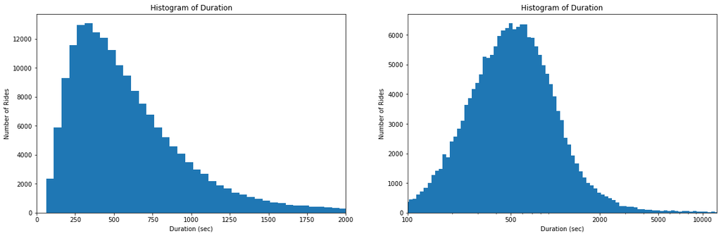

```python
bin_size = 50
plt.figure(figsize=[20,6])

plt.subplot(1, 2, 1)
plt.hist(data=ford_copy, x='duration_sec',
         bins=np.arange(ford_copy.duration_sec.min(), ford_copy.duration_sec.max()+bin_size, bin_size)
        )
plt.xlim(0, 2000)
plt.xlabel('Duration (sec)')
plt.ylabel('Number of Rides')
plt.title('Histogram of Duration')

plt.subplot(1, 2, 2)
plt.hist(data=ford_copy, x='duration_sec',
         bins=10**np.arange(np.log10(ford_copy.duration_sec.min()), np.log10(ford_copy.duration_sec.max())+0.025,
                            0.025)
        )
plt.xscale('log')
plt.xticks([100, 500, 2000, 5000, 10000],['100', '500', '2000', '5000', '10000'])
plt.xlabel('Duration (sec)')
plt.ylabel('Number of Rides')
plt.xlim(100, 12500)
plt.title('Histogram of Duration');
```

```python
base_color = sns.color_palette()[0]
def plot_hist(features, bins_size=100, data=ford_copy, figsize=[18,6]):
    """This function plots histograms"""
    rows = 1
    col = len(features)
    count = 1
    plt.figure(figsize=figsize)
    for i in features:
        plt.subplot(rows, col, features.index(i)+1)
        plt.hist(data=data, x=i,
                bins=np.arange(data[i].min(), data[i].max()+bins_size, bins_size),
                color = base_color
                );
        plt.xlabel(i)
        plt.ylabel('Count')
        plt.title('Distribution of '+ i);

def plot_bar(features, data=ford_copy, figsize=[20,6]):
    """This function plots bar charts"""
    rows = 1
    col = len(features)
    count = 1
    plt.figure(figsize=figsize)
    for i in features:
        plt.subplot(rows, col, features.index(i)+1)
        height = data[i].value_counts()
        x = data[i].value_counts().index
        plt.bar(data=data, x=x, height=height, color=base_color);
        plt.xlabel(i)
        plt.ylabel('Count')
        plt.title('Distribution of '+i);

def plot_box(col, data=ford_copy, figsize=[8,6]):
    """This function plots box plots"""
    plt.figure(figsize=figsize)
    sns.boxplot(data=data, x=col, color=base_color);
    plt.title('Distribution of '+col);
```

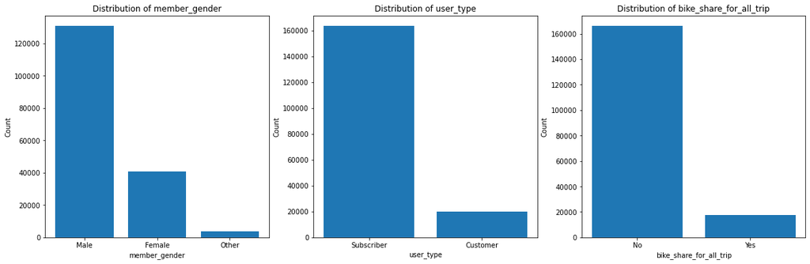

```python
# Nominal Features
items = ['member_gender', 'user_type', 'bike_share_for_all_trip']

plot_bar(features=items)
```

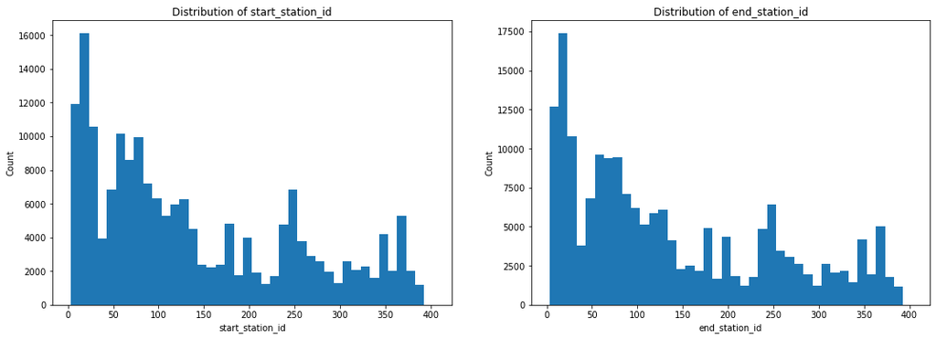

```python
# Stations
vars = ['start_station_id', 'end_station_id']

plot_hist(features=vars, bins_size=10)
```

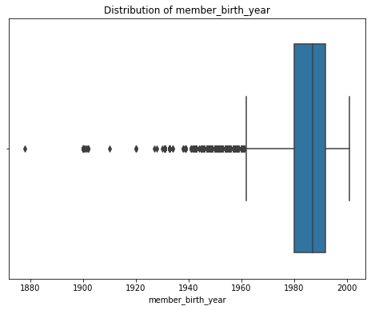

```python
# Birth Year
plot_box(data=ford_copy, col='member_birth_year')
```

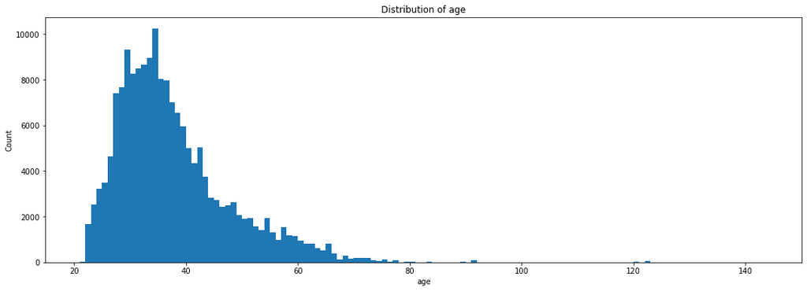

```python
# Age
plot_hist(['age'], bins_size=1)
```

### Discuss the distribution(s) of your variable(s) of interest. Were there any unusual points? Did you need to perform any transformations?

The Distribution of the Duration feature introduced us to a highly skewed curve - after setting a small bin size and magnifying the graph on a small area. The histogram proved that the Duration was a unimodal curve. However, a log scale provided a more normal distribution than the previous, but it still had a longer right tail than a left tail.

### Of the features you investigated, were there any unusual distributions? Did you perform any operations on the data to tidy, adjust, or change the form of the data? If so, why did you do this?

AGE: The boxplot revealed that there were outliers in the data dating all the way to 1880. I created an AGE feature revealing that the data is skewed to the right. The data reveals that majority of the users are between 20 and 40.

GENDER: The bar plot reveals that most of the users were male users more than the female and the 'other' gender in the data.

USER TYPE: The bar plot shows that there were more subscribers than casual customers.

BIKE SHARE FOR ALL TRIP: More people did not share their trip data.

STATIONS: The two histograms revealed show a high level of similarity between the start station and the end station. This reveals that there are some stations that receive more users than the others.

## Bivariate Exploration

```python
def plot_scatter(features, y='duration_sec', log=True, alpha=0.1, data=ford_copy, figsize=[18,6]):
    "Plots a scatter plot"
    rows = 1
    col = len(features)
    count = 1
    plt.figure(figsize=figsize)
    for i in features:
        plt.subplot(rows, col, features.index(i)+1)
        plt.scatter(data=data, x=i, y=y, color=base_color, alpha=alpha);
        if log:
            plt.yscale('log')
            plt.yticks([100, 1000, 10000, 100000],['100', '1000', '10000', '100000'])
        plt.ylabel(y)
        plt.title('Distribution of '+i+' against '+y)
        plt.xlabel(i);
```

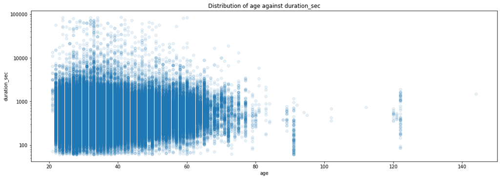

```python
# Scatter Plot between age and duration
plot_scatter(['age'])
```

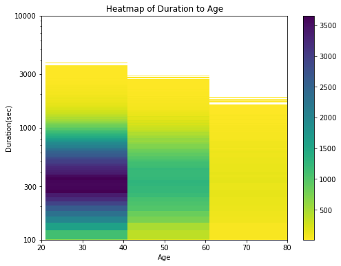

```python
# Heat Map of Age and Duration
plt.figure(figsize=[8, 6])
binx = np.arange(ford_copy.age.min(), ford_copy.age.max()+20, 20)
biny = np.arange(ford_copy.duration_sec.min(), ford_copy.duration_sec.max()+20, 20)
plt.hist2d(data=ford_copy, x='age', y='duration_sec', bins=[binx, biny], cmin=10, cmap='viridis_r')
plt.yscale('log')
plt.yticks([100, 300, 1000, 3000, 10000, 100000],['100', '300', '1000', '3000','10000', '100000'])
plt.colorbar()
plt.ylim(100, 10000)
plt.xlim(20, 80)
plt.ylabel('Duration(sec)')
plt.xlabel('Age')
plt.title('Heatmap of Duration to Age');
```

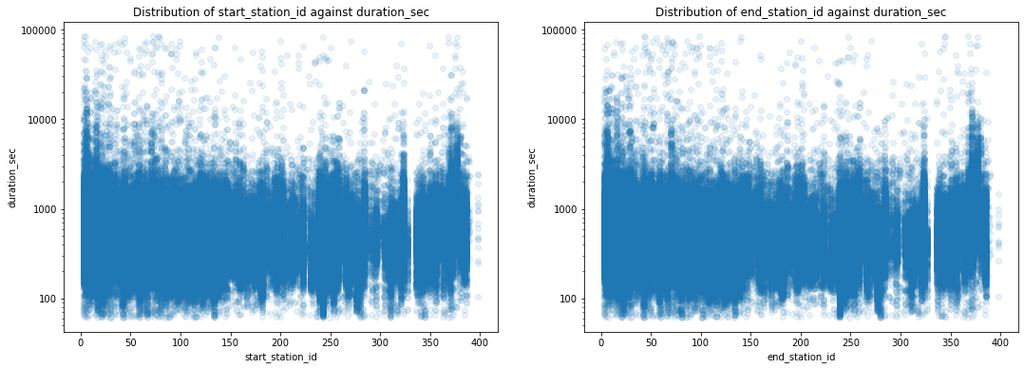

```python
plot_scatter(features=['start_station_id', 'end_station_id'])
```

```python
def plot_heatmap(features, y, bins_x=20, cmin=100, ylim=None, bins_y=20, log=False, data=ford_copy, figsize=[18,6]):
    "Plots a scatter plot"
    rows = 1
    col = len(features)
    count = 1
    plt.figure(figsize=figsize)
    for i in features:
        plt.subplot(rows, col, features.index(i)+1)
        binx = np.arange(data[i].min(), ford_copy[i].max()+bins_x, bins_x)
        biny = np.arange(data[y].min(), ford_copy[y].max()+bins_y, bins_y)
        plt.hist2d(data=ford_copy, x=i, y=y, bins=[binx, biny], cmin=cmin, cmap='viridis_r')
        plt.colorbar()
        if log and y=='duration_sec':
            plt.yscale('log')
            plt.yticks([100, 300, 1000, 3000, 10000, 30000, 100000],['100', '300', '1000', '3000', '10000', '30000', '100000'])
            plt.ylim(100, 10000)
        if y=='age':
            plt.ylim(ylim)
        plt.ylabel(y)
        plt.title('Heat map of '+i+' against '+y)
        plt.xlabel(i);
```

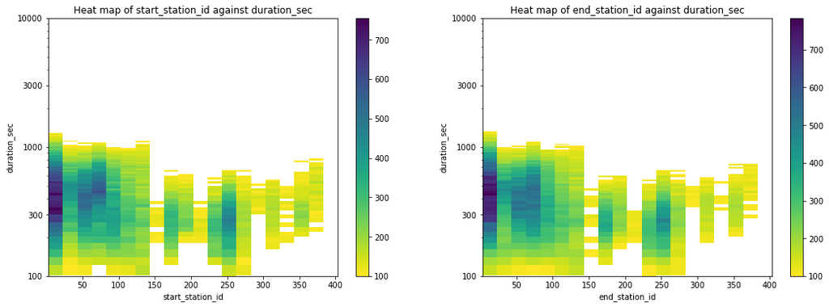

```python
plot_heatmap(features=['start_station_id', 'end_station_id'], y='duration_sec', log=True)
```

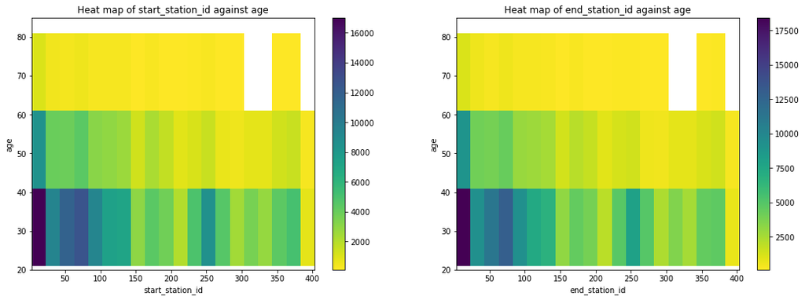

```python
plot_heatmap(features=['start_station_id', 'end_station_id'], y='age', ylim=(20, 85))
```

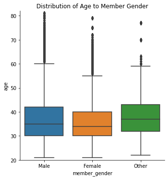

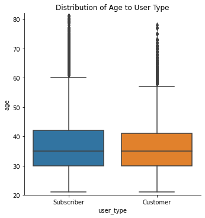

```python
sns.catplot(data=ford_copy, x='member_gender', y='age', kind='box', order=['Male', 'Female', 'Other']);
plt.title('Distribution of Age to Member Gender');
plt.ylim(20, 82);
sns.catplot(data=ford_copy, x='user_type', y='age', kind='box',order=['Subscriber', 'Customer']);
plt.title('Distribution of Age to User Type');
plt.ylim(20, 82);
```

### Talk about some of the relationships you observed in this part of the investigation. How did the feature(s) of interest vary with other features in the dataset?

Age and Duration:

These two features had a slightly negative correlation to each other. Younger participants rode the bikes more than the older users. With the alpha value in the scatter plot set to as low as 1/10, there was a gradual decline observed as the age increased.

The heatmap gave a clearer indication that the most active users were between the age of 20-40 going for bike rides. This group was closely followed by the 40-60 group. Lastly the 60-80 group.

### Did you observe any interesting relationships between the other features (not the main feature(s) of interest)?

Stations and Duration:

The scatter plots of start_station_id and end_station_id revealed the same thing. Some stations in the data received higher logs of the duration in comparison to others. The heatmaps revealed that on average the lower id stations were logging a lot more rides than others. This could either be attributed to more bikes at the station, a high population in the area, or a culture of bike riding around the areas in those stations. Could age, gender and user type be attributed to this too?

Age and Stations:

The Heatmap reveals that the most populous age group is the 20-40 group, mostly found in the first few stations. Other age groups are not as active across stations.

Age and User Type:

The box plot revealed that the Subscriber and Customer ages were roughly the same with a median of 35 across both categories.

Age and Genders:

The median age of the male riders is about 35 while the female riders is slightly lower than that of the male riders. The riders who identified as others had a median age higher than that of the male riders.

## Multivariate Exploration

```python
def sns_scatter(features, x, y='duration_sec', log=True, data=ford_copy, figsize=[18,6]):
    "Plots a scatter plot"
    rows = 1
    col = len(features)
    count = 1
    plt.figure(figsize=figsize)
    for i in features:
        plt.subplot(rows, col, features.index(i)+1)
        sns.scatterplot(data=data, x=x, y=y, hue=i);
        if log:
            plt.yscale('log')
            plt.yticks([100, 1000, 10000, 100000],['100', '1000', '10000', '100000'])
        plt.ylabel('Duration(sec)')
        plt.title('Distribution of '+x+' against '+y+' with a hue of '+i);
```

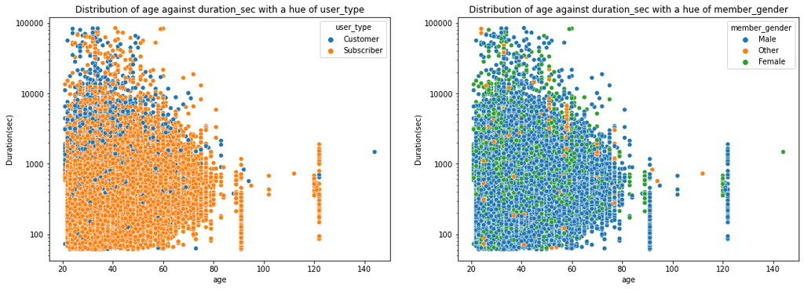

```python
sns_scatter(features=['user_type', 'member_gender'], x='age')
```

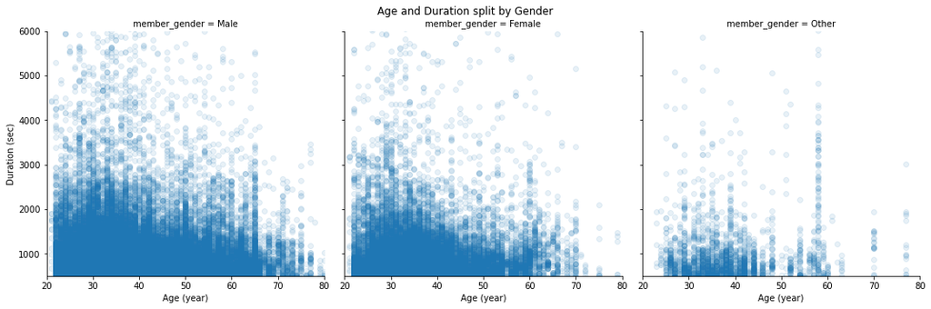

```python
g = sns.FacetGrid(data = ford_copy, col = 'member_gender', col_wrap = 3, height = 5,
                  xlim = [20, 80], ylim = [500, 6000],
                 col_order=['Male', 'Female', 'Other']
                 )
g.map(plt.scatter, 'age', 'duration_sec', alpha=0.1)
g.set_xlabels('Age (year)')
g.set_ylabels('Duration (sec)')
g.fig.subplots_adjust(top=0.9)
g.fig.suptitle('Age and Duration split by Gender');
```

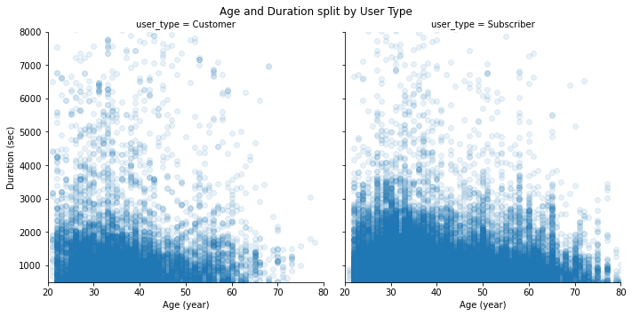

```python
g = sns.FacetGrid(data = ford_copy, col = 'user_type', col_wrap = 2, height = 5,
                 xlim = [20, 80], ylim = [500, 8000]
                         )
g.map(plt.scatter, 'age', 'duration_sec', alpha=0.1)
g.set_xlabels('Age (year)')
g.set_ylabels('Duration (sec)')
g.fig.subplots_adjust(top=0.9)
g.fig.suptitle('Age and Duration split by User Type');
```

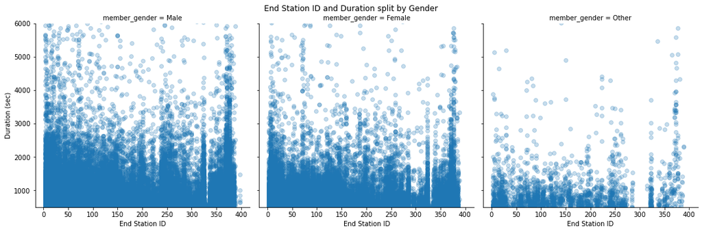

```python
g = sns.FacetGrid(data = ford_copy, col = 'member_gender', col_wrap = 3, height = 5,
                  ylim = [500, 6000],
                 col_order=['Male', 'Female', 'Other']
                 )

g.map(plt.scatter, 'end_station_id', 'duration_sec', alpha=0.25)
g.set_xlabels('End Station ID')
g.set_ylabels('Duration (sec)')
g.fig.subplots_adjust(top=0.9)
g.fig.suptitle('End Station ID and Duration split by Gender');
```

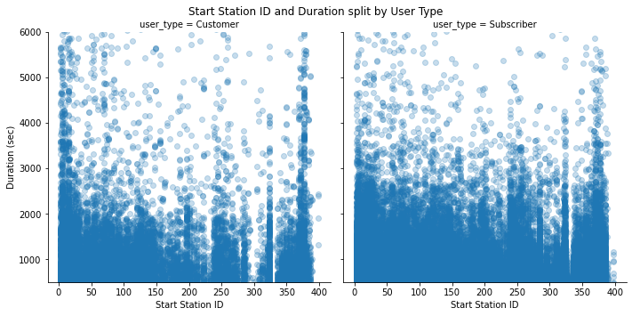

```python
g = sns.FacetGrid(data = ford_copy, col = 'user_type', col_wrap = 2, height = 5,
                  ylim = [500, 6000]
                 )
g.map(plt.scatter, 'start_station_id', 'duration_sec', alpha=0.25)
g.set_xlabels('Start Station ID')
g.set_ylabels('Duration (sec)')
g.fig.subplots_adjust(top=0.9)
g.fig.suptitle('Start Station ID and Duration split by User Type');
```

### Talk about some of the relationships you observed in this part of the investigation. Were there features that strengthened each other in terms of looking at your feature(s) of interest?

Age and Duration - User Type

Both the scatter plots revealed that there was an almost normal curve. Both curves were skewed to the right. The peak for the susbcribers was much higher than that of the customers.

Age and Duration - Gender

There were more males in the lower regions of the 20 - 40 age group than there were in the female category. It was also interesting to note that the 60 - 80 category also showed more men in there than women in the same category. The gender other was most populous between the 25-50 range, but not as compared to the male and female categories.

Stations and Duration - Gender

These curves provided the same result. The distribution of males was almost identical to that of the females and others.

These curves provided the same result. The distribution of Subscribers was denser than that of the customers but both graphs visually had the same curve.

### Were there any interesting or surprising interactions between features?

Age and Duration - User Type

It was interesting to see that the riders who took the longer rides were customers than subscribers. Perhaps these riders were not from the city and wanted to spend longer periods with the bikes.

Age and Duration - Gender

The scatter plot reveals that both males and females took longer rides despite what we might naturally presume that females would take shorter durations. All genders are all in the pool of shorter rides making the graph densely populated in the lower regions.